# Lab7 Daniel Kwong

https://github.com/daniellkwong/GSB544.git

## The Data

```python
import pandas as pd
ha = pd.read_csv("https://www.dropbox.com/s/aohbr6yb9ifmc8w/heart_attack.csv?dl=1")

ha.head()
```

|  | age | sex | cp | trtbps | chol | restecg | thalach | output |
| --- | --- | --- | --- | --- | --- | --- | --- | --- |
| 0 | 63 | 1 | 3 | 145 | 233 | 0 | 150 | 1 |
| 1 | 37 | 1 | 2 | 130 | 250 | 1 | 187 | 1 |
| 2 | 56 | 1 | 1 | 120 | 236 | 1 | 178 | 1 |
| 3 | 57 | 0 | 0 | 120 | 354 | 1 | 163 | 1 |
| 4 | 57 | 1 | 0 | 140 | 192 | 1 | 148 | 1 |

## Part One: Fitting Models

```python
import numpy as np
from sklearn.model_selection import *
from sklearn.preprocessing import *
from sklearn.pipeline import *
from sklearn.metrics import *
from sklearn.neighbors import *
from sklearn.linear_model import *
from sklearn.tree import *

X = ha.drop(columns=["output"])
y = ha["output"]

X_train, X_test, y_train, y_test = train_test_split(
    X, y, test_size=0.2, random_state=42, stratify=y
)

def evaluate_model(model, name):
    cv_auc = cross_val_score(model, X_train, y_train, scoring="roc_auc", cv=5).mean()
    model.fit(X_train, y_train)
    preds = model.predict(X_test)
    cm = confusion_matrix(y_test, preds)
    probs = model.predict_proba(X_test)[:, 1]
    test_auc = roc_auc_score(y_test, probs)

    print(name)
    print(f"Cross-validated ROC AUC: {cv_auc}")
    print(f"Test ROC AUC: {test_auc}")
    print(cm)

    return probs
```

# Q1 KNN

```python
k_values = [1, 3, 5, 7, 9, 11, 15]
results = []

for k in k_values:
    temp_model = Pipeline([
        ("scaler", StandardScaler()),
        ("knn", KNeighborsClassifier(n_neighbors=k))
    ])

    auc = cross_val_score(temp_model, X_train, y_train,
                          cv=5, scoring="roc_auc").mean()
    results.append((k, auc))

results
```

```
[(1, np.float64(0.7383592132505177)),
 (3, np.float64(0.8341899585921325)),
 (5, np.float64(0.8516977225672878)),
 (7, np.float64(0.8468310041407868)),
 (9, np.float64(0.8522826086956522)),
 (11, np.float64(0.8615696169772257)),
 (15, np.float64(0.8652523291925466))]
```

```python
best_k = max(results, key=lambda x: x[1])[0]
best_k
```

```
15
```

```python
knn_model = Pipeline([
    ("scaler", StandardScaler()),
    ("knn", KNeighborsClassifier(n_neighbors=best_k))
])

knn_probs = evaluate_model(knn_model, "KNN")
```

```
KNN
Cross-validated ROC AUC: 0.8652523291925466
Test ROC AUC: 0.6956233421750663
[[14 12]
 [ 9 20]]
```

Smaller values of k tended to make the model more flexible but also more sensitive to noise, while larger values smoothed out predictions. I evaluated several options using cross-validated ROC AUC and selected k=15 since that performed the best, before generating the final confusion matrix and ROC curve.

# Q2 Logistic Regression

```python
C_values = [0.001, 0.01, 0.1, 1, 10, 100]
log_results = []

for c in C_values:
    temp_log = Pipeline([
        ("scaler", StandardScaler()),
        ("logreg", LogisticRegression(C=c, max_iter=5000))
    ])

    auc = cross_val_score(temp_log, X_train, y_train,
                          cv=5, scoring="roc_auc").mean()
    log_results.append((c, auc))

log_results
```

```
[(0.001, np.float64(0.8640010351966874)),
 (0.01, np.float64(0.8645005175983437)),
 (0.1, np.float64(0.8603856107660455)),
 (1, np.float64(0.860085403726708)),
 (10, np.float64(0.8613302277432713)),
 (100, np.float64(0.8613302277432713))]
```

```python
best_C = max(log_results, key=lambda x: x[1])[0]
best_C
```

```
0.01
```

```python
log_model = Pipeline([
    ("scaler", StandardScaler()),
    ("logreg", LogisticRegression(C=best_C, max_iter=500))
])

log_probs = evaluate_model(log_model, "Logistic Regression")
```

```
Logistic Regression
Cross-validated ROC AUC: 0.8645005175983437
Test ROC AUC: 0.7957559681697612
[[16 10]
 [ 4 25]]
```

I tested multiple values of the penalty parameter and ensured that the model was able to converge properly. After comparing the cross-validated ROC AUC scores across these variations, I selected c=0.01 to use for the final evaluation and interpretation of coefficients.

# Q3 Decision Tree

```python
depth_values = [2, 3, 4, 5, 6, 8, 10]
tree_results = []

for d in depth_values:
    temp_tree = Pipeline([
        ("tree", DecisionTreeClassifier(max_depth=d, random_state=42))
    ])

    auc = cross_val_score(temp_tree, X_train, y_train,
                          cv=5, scoring="roc_auc").mean()
    tree_results.append((d, auc))

tree_results
```

```
[(2, np.float64(0.769532867494824)),
 (3, np.float64(0.7617766563146998)),
 (4, np.float64(0.7802717391304348)),
 (5, np.float64(0.7634355590062112)),
 (6, np.float64(0.7627743271221532)),
 (8, np.float64(0.7279321946169772)),
 (10, np.float64(0.7350051759834368))]
```

```python
best_depth = max(tree_results, key=lambda x: x[1])[0]
best_depth
```

```
4
```

```python
tree_model = Pipeline([
    ("tree", DecisionTreeClassifier(max_depth=best_depth, random_state=42))
])

tree_probs = evaluate_model(tree_model, "Decision Tree")
```

```
Decision Tree
Cross-validated ROC AUC: 0.7802717391304348
Test ROC AUC: 0.7141909814323608
[[18  8]
 [ 8 21]]
```

Shallow trees tended to underfit, while deeper trees captured more complexity but risked overfitting. I compared multiple versions using cross-validated ROC AUC and chose a depth of 4 for the final analysis, including its feature importance ranking and ROC curve.

# Q4 Interpretation

```python
coef_table = pd.DataFrame({
    "feature": X.columns,
    "coef": log_model.named_steps["logreg"].coef_[0]
}).sort_values("coef", key=np.abs, ascending=False) #help from ChatGPT

imp_table = pd.DataFrame({
    "feature": X.columns,
    "importance": tree_model.named_steps["tree"].feature_importances_
}).sort_values("importance", ascending=False) #help from ChatGPT

print("Logistic Regression Coefficients:")
print(coef_table)

print("Decision Tree Importances:")
print(imp_table)
```

```
Logistic Regression Coefficients:
   feature      coef
6  thalach  0.281641
2       cp  0.250365
1      sex -0.221231
0      age -0.129660
5  restecg  0.094455
3   trtbps -0.061967
4     chol -0.023530
Decision Tree Importances:
   feature  importance
2       cp    0.446129
6  thalach    0.171669
0      age    0.123938
1      sex    0.117217
3   trtbps    0.109069
4     chol    0.031979
5  restecg    0.000000
```

In the Logistic Regression model, the two strongest predictors of heart attack risk were thalach and cp. Both had positive coefficients, meaning higher heart rate and certain types of chest pain made the model more likely to predict someone as high risk. Some predictors, like sex and age, had small negative coefficients, meaning they slightly lowered the predicted risk. The remaining variables—restecg, trtbps, and chol—had very small effects, so they did not influence the model much.

In the Decision Tree model, cp was the most important variable, meaning the tree used it the most when making splits. Thalach and age were also important and helped the tree separate high-risk and low-risk patients. Other variables like sex, trtbps, and chol had smaller effects. Restecg had an importance of zero, meaning the tree did not use it at all.

# Q5 ROC Curve

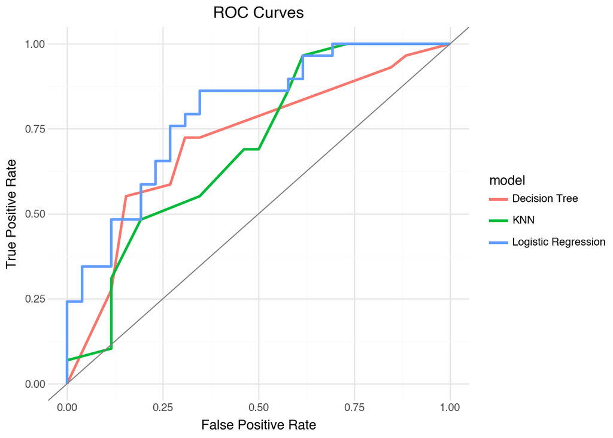

```python
from plotnine import *

knn_fpr, knn_tpr, _ = roc_curve(y_test, knn_probs)
log_fpr, log_tpr, _ = roc_curve(y_test, log_probs)
tree_fpr, tree_tpr, _ = roc_curve(y_test, tree_probs)

roc_df = pd.DataFrame({
    "fpr": np.concatenate([knn_fpr, log_fpr, tree_fpr]),
    "tpr": np.concatenate([knn_tpr, log_tpr, tree_tpr]),
    "model": (["KNN"] * len(knn_fpr))
             + (["Logistic Regression"] * len(log_fpr))
             + (["Decision Tree"] * len(tree_fpr))
}) #help from ChatGPT

(
    ggplot(roc_df, aes(x="fpr", y="tpr", color="model"))
    + geom_line(size=1.2)
    + geom_abline(color="gray")
    + labs(
        title="ROC Curves",
        x="False Positive Rate",
        y="True Positive Rate"
    )
    + theme_minimal()
)
```

## Part Two: Metrics

```python
specificity_scorer = make_scorer(recall_score, pos_label=0)
recall_scorer = make_scorer(recall_score, pos_label=1)
precision_scorer = make_scorer(precision_score, pos_label=1)

def compute_metrics(model, name):
    recall_cv = cross_val_score(model, X_train, y_train, cv=5, scoring=recall_scorer).mean()

    precision_cv = cross_val_score(model, X_train, y_train, cv=5, scoring=precision_scorer).mean()

    specificity_cv = cross_val_score(model, X_train, y_train, cv=5, scoring=specificity_scorer).mean()

    print(name)
    print(f"Specificity: {specificity_cv}")
    print(f"Recall: {recall_cv}")
    print(f"Precision: {precision_cv}")

compute_metrics(knn_model, "KNN")
compute_metrics(log_model, "Logistic Regression")
compute_metrics(tree_model, "Decision Tree")
```

```
KNN
Specificity: 0.7019047619047619
Recall: 0.8713768115942029
Precision: 0.774269592476489
Logistic Regression
Specificity: 0.6033333333333333
Recall: 0.8967391304347826
Precision: 0.7281609195402299
Decision Tree
Specificity: 0.7128571428571429
Recall: 0.7782608695652173
Precision: 0.7705128205128206
```

## Part Three: Discussion

# Q1

The hospital wants to avoid cases where a high-risk patient is incorrectly predicted as low-risk. The most important metric is Recall. Among the three models, Logistic Regression has the highest recall (0.8967), meaning it correctly identifies about 90% of patients who are actually at risk.

# Q2

The hospital wants to avoid false positives. Precision is the best metric, since it measures how many predicted high-risk patients actually are high-risk. The model with the highest precision is KNN (0.7743). Since KNN has the strongest precision, it is the best recommendation for saving hospital bed space. With this model, around 77% of the patients it flags as high-risk actually need monitoring.

# Q3

The hospital interested in understanding which patient features are related to heart attack risk. The best model for this is Logistic Regression, which produces clear and meaningful coefficients that show the direction and strength of each variable’s relationship with risk. The model’s ROC AUC from earlier results shows it performs well overall, so the hospital can expect good predictions while also learning which factors are most important.

# Q4

The hospital wants to compare how well new doctors diagnose patients relative to the model. The goal is to use a balanced overall performance metric such as ROC AUC or accuracy as a benchmark for evaluating trainees. Looking at the ROC curves, Logistic Regression’s curve stays highest overall and stays closest to the top-left corner, which means it has the best AUC. Because of this, Logistic Regression is the best model to use as the benchmark for evaluating how well the new doctors diagnose heart attack risk.

## Part Four: Validation

```python
ha_validation = pd.read_csv("https://www.dropbox.com/s/jkwqdiyx6o6oad0/heart_attack_validation.csv?dl=1")
```

```python
X_val = ha_validation.drop(columns=["output"])
y_val = ha_validation["output"]

def validate_model(model, name):
    preds = model.predict(X_val)
    probas = model.predict_proba(X_val)[:, 1]

    cm = confusion_matrix(y_val, preds)
    auc = roc_auc_score(y_val, probas)
    precision = precision_score(y_val, preds)
    recall = recall_score(y_val, preds)

    print(name)
    print(cm)
    print(f"ROC AUC: {auc}")
    print(f"Precision: {precision}")
    print(f"Recall: {recall}")
```

```python
validate_model(knn_model, "KNN")
validate_model(log_model, "Logistic Regression")
validate_model(tree_model, "Decision Tree")
```

```
KNN
[[ 9  2]
 [ 5 14]]
ROC AUC: 0.9425837320574162
Precision: 0.875
Recall: 0.7368421052631579
Logistic Regression
[[ 9  2]
 [ 4 15]]
ROC AUC: 0.9234449760765551
Precision: 0.8823529411764706
Recall: 0.7894736842105263
Decision Tree
[[10  1]
 [ 5 14]]
ROC AUC: 0.799043062200957
Precision: 0.9333333333333333
Recall: 0.7368421052631579
```

## Part Five: Cohen’s Kappa

```python
def compute_kappa(model, name):
    preds = model.predict(X_val)
    kappa = cohen_kappa_score(y_val, preds)

    print(f"{name} Kappa: {kappa}")
```

```python
compute_kappa(knn_model, "KNN")
compute_kappa(log_model, "Logistic Regression")
compute_kappa(tree_model, "Decision Tree")
```

```
KNN Kappa: 0.5248868778280543
Logistic Regression Kappa: 0.5852534562211982
Decision Tree Kappa: 0.6
```

Cohen’s Kappa is useful when one class is much more common than the other. It tells us how much the model is doing better than random chance. In these situations, Kappa provides a better measure of model performance than accuracy alone. Using Kappa, the Decision Tree scores highest (0.6), followed by Logistic Regression (0.586) and KNN (0.525). This ranking is slightly different from the ROC AUC results, but the differences are small and do not change our overall conclusions. Logistic Regression and KNN still perform well overall, and the Decision Tree still shows weaker general performance despite its slightly higher Kappa. So Kappa offers another useful perspective, but it does not meaningfully alter our earlier findings.